# SNA Tutorial

David N Fisher

15 March 2021

# An introduction to social network analysis

Croft et al 2008 “Exploring Animal Social Networks” is a good basic introductory book.

Note you will need the following R packages: sna vegan ergm ergm.count tnet

## Different types of network data

First we’re going to look at some of the different formats of data that can be turned into networks.

### Edge list

Each line is the IDs of two individuals that interacted

We can pass that to the function “network” as long as we specifiy it is an edgelist

We also need to specify the network is not directed. This means all connections are symmetrical i.e., the association *A -> B* is equal to *B -> A*. There are situations where this is not true e.g., in networks of dominance interactions.

```r
(el = cbind(c(1,1,2),c(2,3,3)))
```

```
##      [,1] [,2]
## [1,]    1    2
## [2,]    1    3
## [3,]    2    3
```

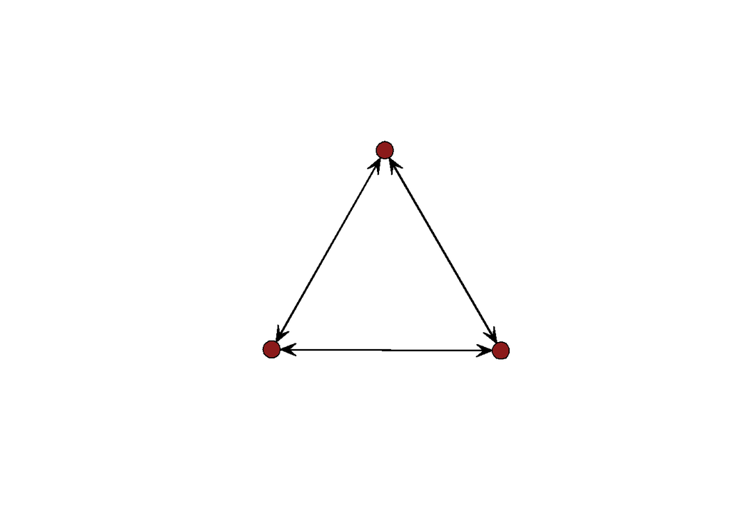

```r
el.net=network(el,matrix.type="edgelist",directed=FALSE)

gplot(el.net, vertex.col="firebrick4")
```

### Group by indivdual matrix

Each line is a group sighting, awith a 1 if that individual was seen in that group, or a 0 if not

To convert this n (number of individuals) x m (number of groups) rectnagular matrix into a n x n square matrix we multiple the GBI matrix by its transpose using the function "%*%t" We then need to set the diagonal of this matrix, which represents self-links, to zero, as we typically don’t consider these.

```r
(gbi=matrix(c(1,1,0,1,0,1,0,1,1),3,3))
```

```
##      [,1] [,2] [,3]
## [1,]    1    1    0
## [2,]    1    0    1
## [3,]    0    1    1
```

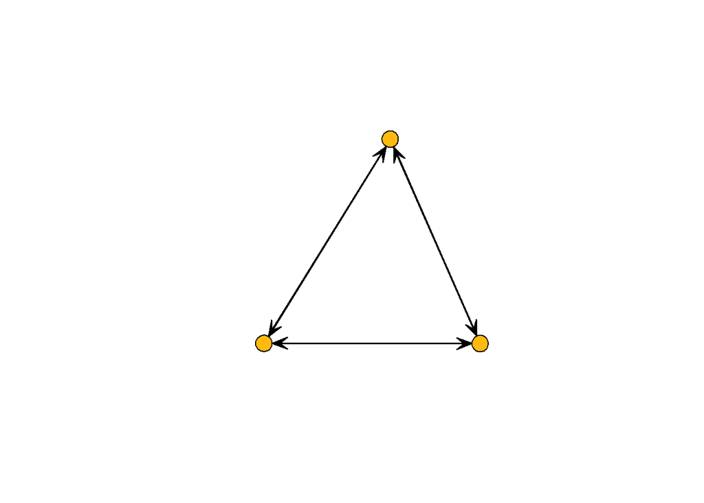

```r
gbi.net=gbi%*%t(gbi)
diag(gbi.net)=0

gplot(gbi.net, vertex.col="darkgoldenrod1")
```

### Association matrix

We can of course directly input the n by n matrix of interactions/associations

Again we can use the “network” function as long as we specify it is an adjacency matrix

```r
(am = matrix(c(0,1,0,0,0,1,1,0,0),3,3))
```

```
##      [,1] [,2] [,3]
## [1,]    0    0    1
## [2,]    1    0    0
## [3,]    0    1    0
```

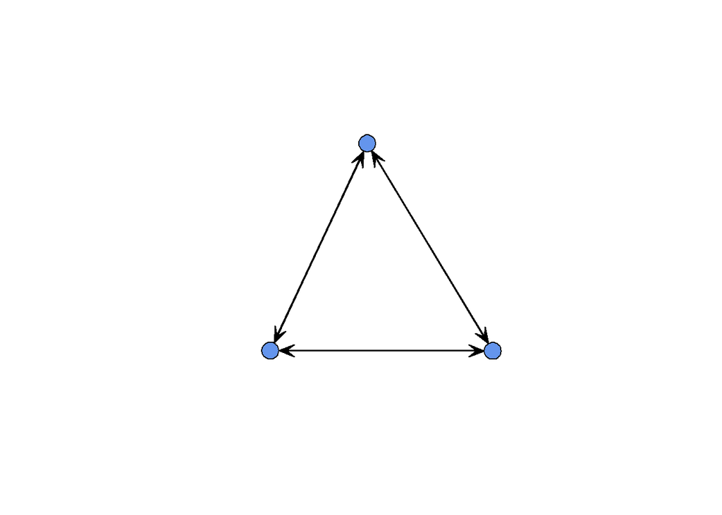

```r
am.net=network(am, matrix.type="adjacency",directed=FALSE)

gplot(am.net, vertex.col="cornflowerblue")
```

*Note all these examples are with “binary” networks, where links either exist, or they do not, hence 0 or 1 in the matrices However, we can represent interactions of different strengths by using values other than 1. These could be counts of interactions, ranging from 1 upwards, or they could be relative measures of interaction strength, ranging from 0-1. The latter case is not handled brilliantly by some network packages*

## Plotting networks

Load a data set from a paper of mine to explore plotting options a bit more. Data are from “Comparing pre- and post-copulatory mate competition using social network analysis in wild crickets”:

> Fisher, Rodríguez-Muñoz, Tregenza 2015: https://academic.oup.com/beheco/article/27/3/912/2366164

```r
load("cricket_network_data.RData")
```

This contains two networks, one based on male crickets fighting each other, the other where they were linked if they mated with the same female.

```r
head(mfnet06sym) #the fighting network
```

```
##    X1 X2 X6 X11 X16 X20 X23 X24 X25 X28 X31 X34 X36 X38 X41 X54 X55 X56 X66 X68
## 1   0  0  0   0   0   0   0   0   0   0   0   0   0   0   0   0   0   1   0   1
## 2   0  0  3   0   0   0   0   0   0   0   0   0   0   0   0   0   0   0   0   0
## 6   0  3  0   0   0   0   0   0   0   0   0   0   0   0   0   1   0   0   1   0
## 11  0  0  0   0   0   0   0   0   0   0   0   0   0   0   0   0   0   0   0   0
## 16  0  0  0   0   0   0   0   0   0   0   0   1   0   0   0   1   0   0   0   0
## 20  0  0  0   0   0   0   0   0   0   0   0   0   0   0   0   0   0   0   0   0
##    X70 X72 X76 X79 X82 X86 X87 X93 X98 X112 X115 X129 X133 X136 X139 X140 X143
## 1    0   0   0   0   0   0   0   0   0    0    0    0    0    0    0    0    0
## 2    0   0   0   0   0   0   0   0   0    0    0    0    0    0    0    0    0
## 6    1   0   0   0   0   0   0   0   0    0    5    0    0    0    0    0    0
## 11   0   0   0   0   0   0   0   0   0    0    0    0    0    0    0    0    0
## 16   0   0   0   0   0   0   0   0   4    0    1    1    0    0    0    0    0
## 20   0   0   0   0   0   0   0   0   0    0    0    0    0    0    0    0    0
##    X144 X150
## 1     0    0
## 2     0    0
## 6     1    1
## 11    0    0
## 16    0    0
## 20    0    0
```

```r
head(mmnet06sym) #the sperm competition network
```

```
##    X1 X2 X6 X11 X16 X20 X23 X24 X25 X28 X31 X34 X36      X38 X41       X54 X55
## 1   0  0  0   0   1   0   0   0   0   0   0   0   0 0.000000   0  0.000000   0
## 2   0  0  0   0   0   0   0   0   0   0   0   0   0 0.000000   0  0.000000   0
## 6   0  0  0   0   0   0   3   0   0   0   0   0   0 4.472136   0 22.583180   0
## 11  0  0  0   0   0   0   0   0   0   0   0   0   0 0.000000   0  0.000000   0
## 16  1  0  0   0   0   0   1   0   0   0   0   0   0 0.000000   0  1.414214   0
## 20  0  0  0   0   0   0   0   0   0   0   0   0   0 0.000000   0  0.000000   0
##    X56 X66 X68 X70 X72 X76 X79 X82 X86 X87 X93      X98 X112     X115 X129 X133
## 1    0   0   0   0   0   0   0   0   0   0   0  0.00000    0 0.000000    0    0
## 2    0   0   0   0   0   0   0   0   0   0   0  0.00000    0 0.000000    0    0
## 6    0   0   0   0   0   0   0   0   0   0   0 20.12461    0 5.744563    0    0
## 11   0   0   0   0   0   0   0   0   0   0   0  0.00000    0 0.000000    0    0
## 16   0   0   0   0   0   0   0   0   0   0   0  0.00000    0 1.732051    0    0
## 20   0   0   0   0   0   0   0   0   0   0   0  0.00000    0 0.000000    0    0
##    X136     X139     X140 X143    X144     X150
## 1     0 0.000000  0.00000    0 0.00000 0.000000
## 2     0 0.000000  0.00000    0 0.00000 0.000000
## 6     0 3.741657 15.87451    0 2.44949 1.414214
## 11    0 0.000000  0.00000    0 0.00000 0.000000
## 16    0 0.000000  0.00000    1 0.00000 0.000000
## 20    0 0.000000  0.00000    0 0.00000 0.000000
```

The data are symmetrical adjacency matrices and include edge weights

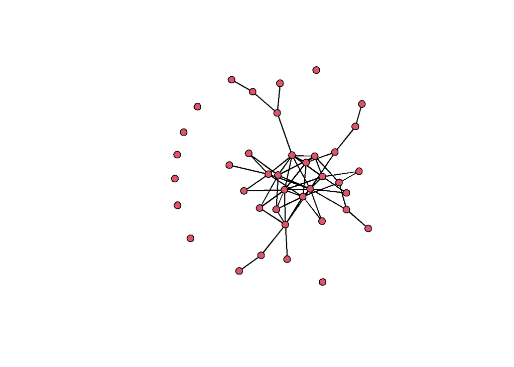

```r
mfnetwork = network(mfnet06sym,
                      directed=F,
                      ignore.eval=FALSE,
                      names.eval="weight")
gplot(mfnetwork, gmode="graph")
```

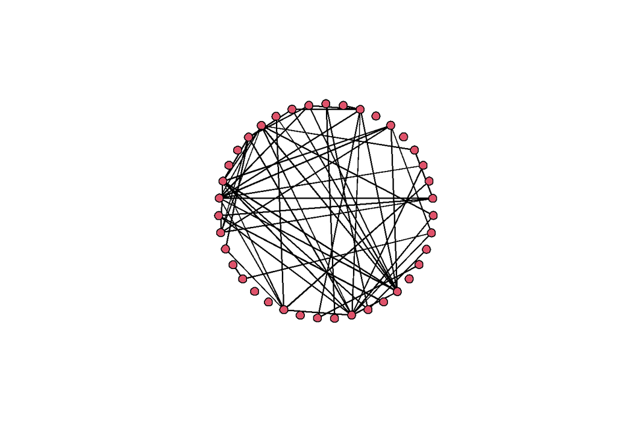

```r
gplot(mfnetwork, gmode="graph", mode="circle")
```

```r
mmnetwork = network(mmnet06sym, #we'll need this later
                    directed=F,
                    ignore.eval=FALSE,
                    names.eval="weight")
```

So far so good, but we want to incorporate traits of our individuals

```r
summary(traits06)
```

```
##        ID       aggression         mass                    flavour
##  1      : 1   Min.   :0.000   Min.   :0.6972   apple           :11
##  10     : 1   1st Qu.:2.000   1st Qu.:0.9163   chocolate       : 8
##  11     : 1   Median :2.000   Median :1.0628   golden retriever: 7
##  12     : 1   Mean   :2.923   Mean   :1.0673   haggis          : 4
##  13     : 1   3rd Qu.:4.000   3rd Qu.:1.2157   nutty           : 9
##  14     : 1   Max.   :8.000   Max.   :1.5305
##  (Other):33
```

We add these as properties of the nodes (a.k.a “vertices”", hence the v). *Note I’ve already ensured the traits are in the same order as the nodes in the network*

```r
mfnetwork %v% "aggression" <- traits06$aggression
mfnetwork %v% "mass" <- traits06$mass

mmnetwork %v% "aggression" <- traits06$aggression
mmnetwork %v% "mass" <- traits06$mass
```

Plot fighting network with range of reds for aggression, vertex size based on mass (squared to increase variation), and edge thickness representing number of interactions

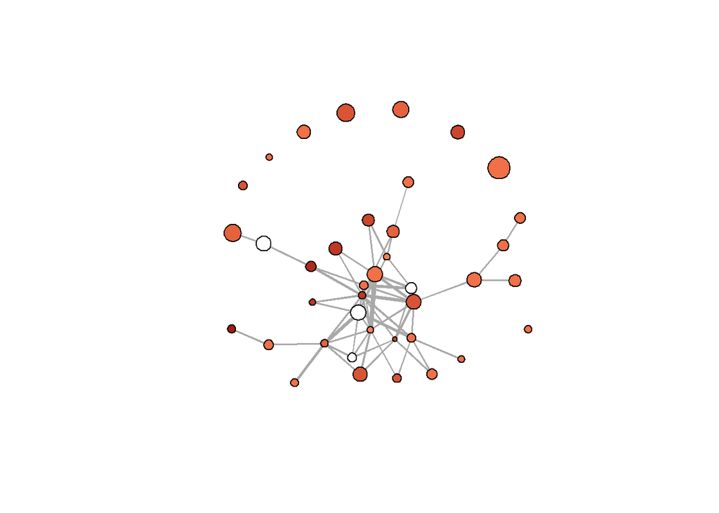

```r
palette(colorRampPalette(c("coral", "darkred"))(10))
gplot(mfnetwork, gmode="graph",
      vertex.cex= (mfnetwork %v% "mass")^2,
      vertex.col=mfnetwork %v% "aggression",
      vertex.border = "black",
      edge.col="darkgrey",
      edge.lwd=mfnetwork %e% "weight")
```

Then plot the sperm competition network with a range of blues for aggression

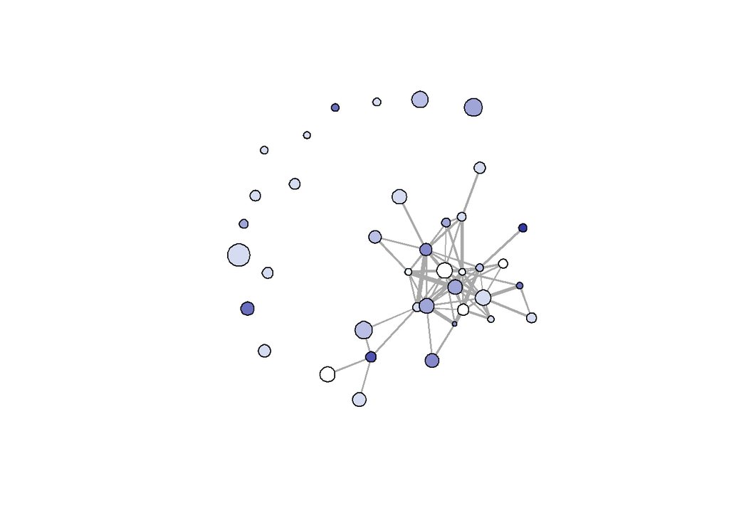

So these are pretty and all, but it is actually kind of hard to compare them visually as the vertex locations change from plot to plot. We we’re going to manually set node coordinates. We sum the two networks to give an overall network, extract the coodinates from it, then use that to plot

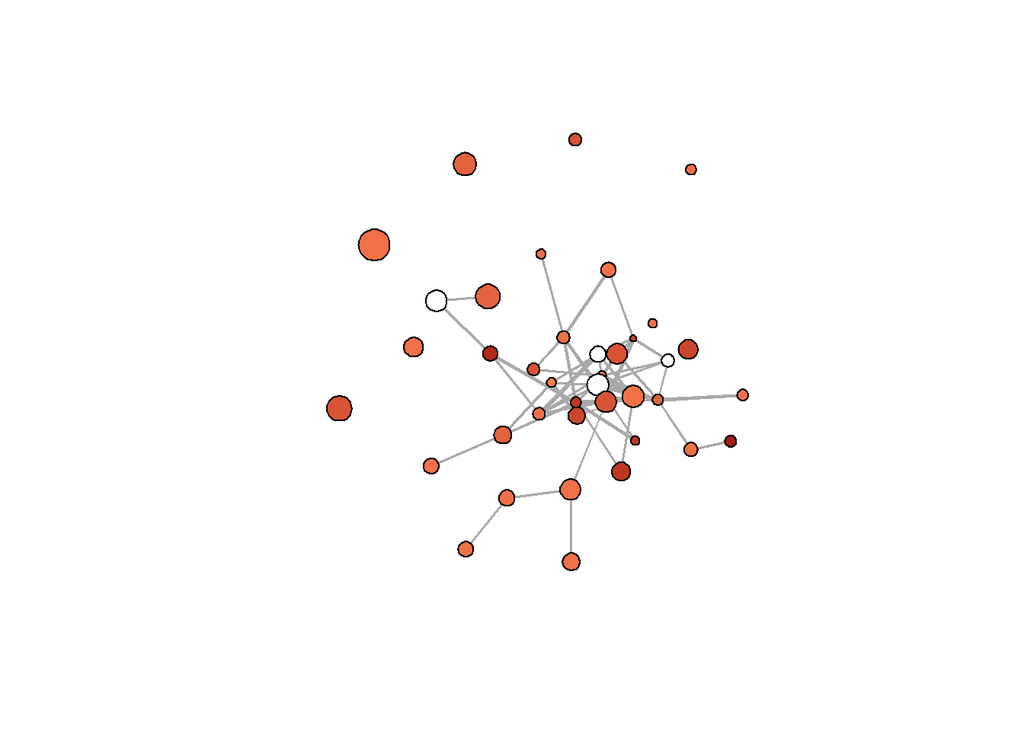

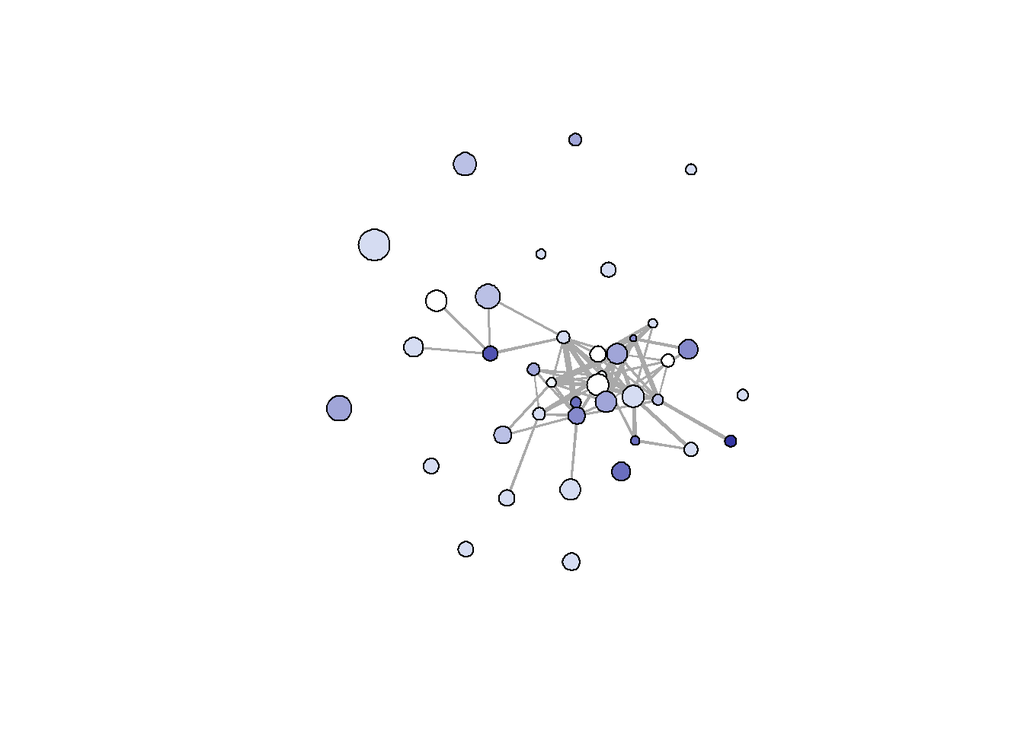

```r
allnetwork<-network(mmnet06sym+mfnet06sym,
                    directed =F,
                    ignore.eval=F,
                    names.eval="weight")
pos.all<-network.layout.fruchtermanreingold(allnetwork, layout.par=NULL )
palette(colorRampPalette(c("coral", "darkred"))(10))
gplot(mfnetwork, gmode="graph",
      vertex.cex= (mfnetwork %v% "mass")^2,
      vertex.col=mfnetwork %v% "aggression",
      edge.col="darkgrey",
      edge.lwd=mfnetwork %e% "weight",
      vertex.border = "black",
      coord=pos.all)
```

## Network characteristics

### Network-level measures

```r
connectedness(mmnetwork)
```

```
## [1] 0.4385965
```

```r
connectedness(mfnetwork)
```

```
## [1] 0.6275304
```

### Individual-level measures

We can also calculate measures for each individual that represent their unique pattern of connections in some way, e.g., “degree” and “betweenness”

I did this for the a question in the BE paper: What is the correlation within-individuals in engagement in pre- and post-copulatory competition.

We can calculate the **unweighted** degree - the number of unique individuals a cricket interacts with

```r
mmnet06.deg<-sna::degree(mmnet06sym,  cmode="outdegree", ignore.eval=T)
mfnet06.deg<-sna::degree(mfnet06sym,  cmode="outdegree", ignore.eval=T)
```

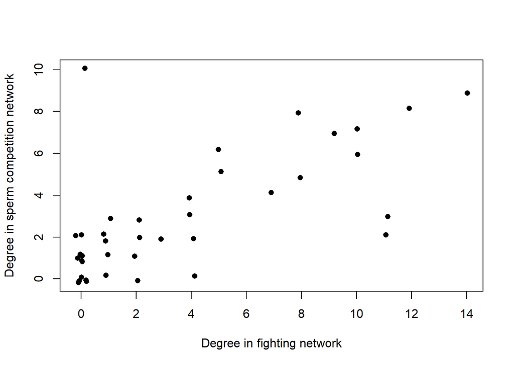

```
##       rho
## 0.6781513
```

I used the **weighted** degree - the total number of interactions an individual has, i.e., summing all their edge weights

```r
mmnet06.wdeg<-sna::degree(mmnet06sym,  cmode="outdegree",ignore.eval=F)
mfnet06.wdeg<-sna::degree(mfnet06sym,  cmode="outdegree",ignore.eval=F)
```

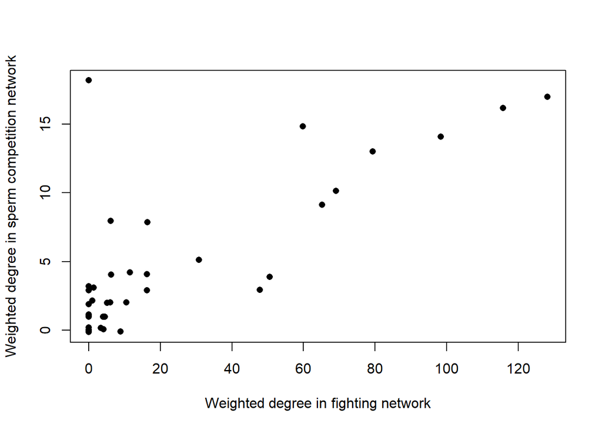

```
##       rho
## 0.7016897
```

## Statistical tests in networks

### Randomisations of node labels

Often we want to answer questions like “Is there an association between aggression and degree?”, or “Is the degree correlation I have found bigger than expected?”

A straightforward way to do the first one is:

```r
cor.test(mmnet06.wdeg, traits06$aggression)
```

```
##
##  Pearson's product-moment correlation
##
## data:  mmnet06.wdeg and traits06$aggression
## t = -1.5103, df = 37, p-value = 0.1395
## alternative hypothesis: true correlation is not equal to 0
## 95 percent confidence interval:
##  -0.5171702  0.0806766
## sample estimates:
##        cor
## -0.2409744
```

However, as degree scores are non-independent, they violate the assumptions of the test, and so the p-value is not valid.

Instead, what we do is compare the observed correlation (-0.24 in this case) with a distribution of 1000 correlations from networks where the node identities have been randomised. See:

> Croft et al. 2011: https://www.sciencedirect.com/science/article/pii/S0169534711001455

So we will compare the observed correlation from this network

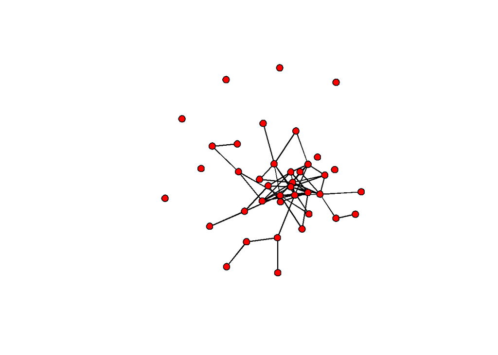

vs. from a set of randomised networks

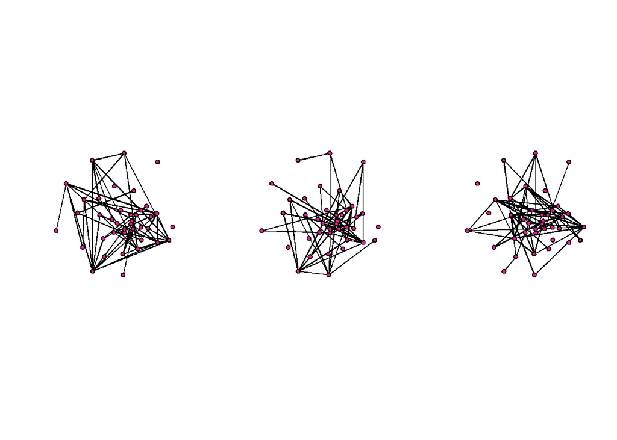

```r
obs_r = cor.test(mmnet06.wdeg, traits06$aggression)$est
r_r = numeric(1000)
for (i in 1:1000) {
ran_net = rmperm(mmnetwork) #randomise network
ran_wdeg = sna::degree(ran_net,  cmode="outdegree",ignore.eval=F) #calculate degree
r_r[i] = cor.test(ran_wdeg, traits06$aggression)$est #calculate correlation and place in vector
}
```

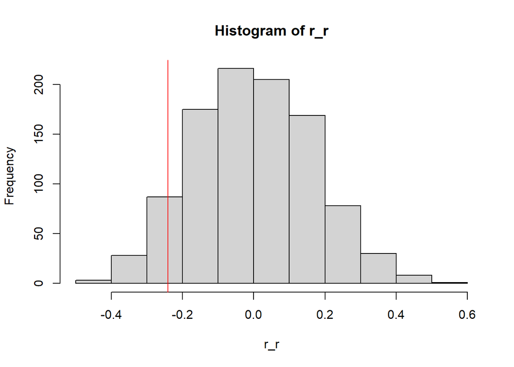

What is our p value? As we have conducted a two-tailed test (we are looking to see if the observed correlation is larger or smaller than the randomised ones) we take the smaller of the total number of occassions that the observed is larger or small than the distribution of randomised values, divide by the number of randomisations (1000), then multiply by 2 (as two-tailed). So if the observed value is larger than 999 of the randomisations, it is smaller than 1, so we take 1, divide by 1000, multiply by 2, giving a p value of 0.002

```r
min(c(sum(obs_r<r_r), sum(obs_r>r_r))) /500 #note /1000*2 simplifies to /500
```

```
## [1] 0.14
```

So the observed correlation is not significantly different from what we would expect by chance.

### Randomisation of data

Sometimes our data collection *method* will tend towards certain types of network structure or relationships, even when there is no *biological* process generating that relationship. For example, males might be more likely to be observed than females with a particular method we are using. This would lead to males having more connections. But does this actually represent higher sociability for males? No. To confirm that, we need to conduct our analyses accounting for sighting rate.

Until recently, this would have been done by randomising the data stream, such as your group-by-individual matrix, where the sighting rates of individuals are maintained but the exact pattern of connections is randomised. So you repeat the model “network_metric ~ sex” 1000 times, each time using a new randomised data set. See:

> Farine & Whitehead 2015: https://besjournals.onlinelibrary.wiley.com/doi/10.1111/1365-2656.12418

However, this approach has recently been shown to be anti-conservative, with a false positive rate of much higher than 5%. See:

> Weiss et al. 2020: https://besjournals.onlinelibrary.wiley.com/doi/10.1111/2041-210X.13508

A better approach is to include sighting rate as a fixed effect in our model of interactions (so the model becomes network_metric ~ sex + sighting rate):

> Franks et al. 2020: https://besjournals.onlinelibrary.wiley.com/doi/full/10.1111/2041-210X.13429

While in *some* situations exponential random graph models (see below) have lower error rates:

> Evans, Fisher, Silk 2020: https://academic.oup.com/beheco/article/31/5/1266/5904748

As such, I can’t really recommend the use of datastream permutations for regression-based analysis of networks and other traits.

What may still be fine is randomising the data in order to calculate network-level measures, and then comparing those with the observed value. These need to be **biologically valid** null models however. Comparing a real network to completely randomised data has been likened to:

> *“Comparing a skyscraper to a pile of rubble”*

So you *need* to design your randomisations such that observations are only swapped within the same location, or in the same year, or however your data is structured. This can be challenging and often needs custom code. One solution I found was using “group_by” (from the tidyverse), grouping my edgelist by both “timepoint” and “colony ID” (*this was for an analysis on social interactions in colonies of social spiders over time*). I then randomised the identity of one ID in each edge (using “new_ID2 = sample(ID2, replace = F)”), and recalculated the network and appropriate statistic (1000 times…). I am not showing that here as it is ugly long bespoke to the dataset and the question. But be aware that you need appropriate null models!

## Correlating networks

We might want to know if two different networks, of the same dimensions, are correlated. So do more genetically related individuals interact more with each other, or do individuals closer in space interact more with each other? This requires the networks to be the same size and in the same order, I’ve already sorted this out for the data we are using

*Note we can’t correlate networks that are different dimensions. In general, comparing networks with different dimensions is quite difficult.*

### Mantel test

One option is the mantel test:

```r
mantel(mfnet06sym, mmnet06sym)
```

```
##
## Mantel statistic based on Pearson's product-moment correlation
##
## Call:
## mantel(xdis = mfnet06sym, ydis = mmnet06sym)
##
## Mantel statistic r: 0.4605
##       Significance: 0.001
##
## Upper quantiles of permutations (null model):
##    90%    95%  97.5%    99%
## 0.0571 0.0842 0.1095 0.1601
## Permutation: free
## Number of permutations: 999
```

### Network regression

This is fine, but we might want to control for some other things. We did this for a question in the BE paper, looking at the relationship between the intensity of pre- and post-copulatory competition within pairs of competing males. We wanted to look at the correlation between their interaction strength in the fighting network and the interaction strength in the sperm comp network, while controlling for how much the males overlapped in space and time

We can do that with a network regression:

```r
sperm.pred06<- list(mmnet06sym, mtime06, mspace06)

sperm.model06<-netlm(mfnet06sym, sperm.pred06, intercept=T, mode="graph", nullhyp="qapspp")
summary(sperm.model06)
```

```
##
## OLS Network Model
##
## Residuals:
##           0%          25%          50%          75%         100%
## -2.150542592 -0.054652251 -0.009498181  0.013078853  3.877989719
##
## Coefficients:
##             Estimate     Pr(<=b) Pr(>=b) Pr(>=|b|)
## (intercept) -0.031140481 0.214   0.786   0.215
## x1           0.034187454 0.999   0.001   0.001
## x2           0.004515407 0.997   0.003   0.003
## x3           0.070134348 1.000   0.000   0.000
##
## Residual standard error: 0.4264 on 737 degrees of freedom
## Multiple R-squared: 0.3528   Adjusted R-squared: 0.3502
## F-statistic: 133.9 on 3 and 737 degrees of freedom, p-value:     0
##
##
## Test Diagnostics:
##
##  Null Hypothesis: qapspp
##  Replications: 1000
##  Coefficient Distribution Summary:
##
##        (intercept)       x1       x2       x3
## Min       -3.11820 -3.04795 -2.77624 -3.24199
## 1stQ      -1.35227 -0.60771 -0.62509 -0.66101
## Median    -0.85183 -0.08309 -0.04890 -0.09776
## Mean      -0.87525 -0.04283  0.01942  0.06005
## 3rdQ      -0.39156  0.44199  0.67493  0.68626
## Max        1.65088  4.81466  4.17244  4.75031
```

*Note we might want to rescale each variable to equivalent units by doing something like this:*

```r
s.mmnet06sym<- (mmnet06sym-mean(mmnet06sym))/sd(mmnet06sym)
s.mtime06 <- (mtime06 -mean(mtime06))/sd(mtime06)
s.mspace06 <- (mspace06 -mean(mspace06))/sd(mspace06)
```

*Can do that for each variable and then repeat*

### Exponential Random Graph Models

If we want to get **really** fancy, we can fit a ERGM. This models the probability of links forming in a network, given what predictor variables you specify. The best thing about ERGMs is, you can use node-level and dyad-level covariates (including another network), and network structure-based terms. check out this paper on ERGMs for animal behaviour research here:

> Silk & Fisher 2017: https://www.sciencedirect.com/science/article/pii/S0003347217302543

So we’re going to fit an ERGM to the fighting network. We want to see if the sperm competition network influences it’s structure, while controlling for the overlap in space and time. We are also including a cricket’s mass and aggression as node-level covariates, to see if these variables influence the number of fights a cricket has.

Note we use the “CMP” term as Using it fits a “Conway-Maxwell-Poisson” distribution that is Poisson when its coefficient is 0 and geometric when its coefficient is 1, as this distribution suits counts of interactions. We use the “nonzero” term to model the probability that any two crickets may not interact. We expect this term to be *negative* as most pairs of crickets do **not** interact (i.e., the network is “sparse”; as is typically true for animal social networks)

```r
ergm_fit<- ergm(mfnetwork ~   CMP + nonzero +
                     nodecov("mass")+ nodecov("aggression") +
                     edgecov(s.mtime06) + edgecov(s.mspace06) + edgecov(s.mmnet06sym),
                    reference=~Poisson, response="weight")
summary(ergm_fit)
```

```
##
## ==========================
## Summary of model fit
## ==========================
##
## Formula:   mfnetwork ~ CMP + nonzero + nodecov("mass") + nodecov("aggression") +
##     edgecov(s.mtime06) + edgecov(s.mspace06) + edgecov(s.mmnet06sym)
##
## Iterations:  5 out of 20
##
## Monte Carlo MLE Results:
##                         Estimate Std. Error MCMC % z value Pr(>|z|)
## CMP                    -0.543151   0.443590      0  -1.224   0.2208
## nonzero                -1.853410   0.563268      0  -3.290   0.0010 **
## nodecov.sum.mass       -0.497152   0.237468      0  -2.094   0.0363 *
## nodecov.sum.aggression -0.008697   0.033770      0  -0.258   0.7968
## edgecov.sum.NULL        0.394404   0.084118      0   4.689   <1e-04 ***
## edgecov.sum.NULL.1      0.294865   0.065296      0   4.516   <1e-04 ***
## edgecov.sum.NULL.2      0.034896   0.040100      0   0.870   0.3842
## ---
## Signif. codes:  0 '***' 0.001 '**' 0.01 '*' 0.05 '.' 0.1 ' ' 1
##
##      Null Deviance:     0  on 741  degrees of freedom
##  Residual Deviance: -1133  on 734  degrees of freedom
##
## Note that the null model likelihood and deviance are defined to be 0.
## This means that all likelihood-based inference (LRT, Analysis of
## Deviance, AIC, BIC, etc.) is only valid between models with the same
## reference distribution and constraints.
##
## AIC: -1119    BIC: -1086    (Smaller is better.)
```

Is this model any good? Can look at diagnostics this way (*it is long so not showing here*):

```r
mcmc.diagnostics(ergm_fit)
```

None of the individual p-values for the Geweke convergence diagnostic test are significant (good). Honestly, not sure how worried to be about the fact the joint p-value is significant or the auto-correlation scores given the model says it converged.

## Multilayer networks

Really cool. Check out:

> Silk et al. 2018: https://www.cell.com/trends/ecology-evolution/fulltext/S0169-5347(18)30062-4

> Finn et al. 2019: https://www.sciencedirect.com/science/article/pii/S0003347218304020

> Finn 2021: https://academic.oup.com/cz/article/67/1/81/6081014

> Hasenjager, Silk, Fisher 2021: https://academic.oup.com/cz/article/67/1/45/6124358

END